# ANOVA Butterfiles

2025-11-12

The following data are from an experiment where female butterflies reared on two different host plants were allowed to oviposit on the same two host plants. The data include developmental time for the larvae, the adult weight, and the growth rate of the larvae. Analyse the data to assess effects of maternal vs. larval host plant on one or more response variable. Interpret the results and produce a nice plot to illustrate.

## Load data

```r
butterflies <- read.csv("butterflies.csv")
head(butterflies)
```

```
##   LarvalID LarvalHost Sex MaternalHost MotherID DevelopmentTime AdultWeight
## 1       14   Barbarea   M     Barbarea        9              21        64.2
## 2       22   Barbarea   M     Barbarea        9              22        60.8
## 3       23   Barbarea   F     Barbarea        9              22        53.0
## 4       24   Barbarea   M     Barbarea        9              22        67.8
## 5       25   Barbarea   F     Barbarea        9              22        57.1
## 6       30   Barbarea   F     Barbarea        9              23        88.9
##   GrowthRate
## 1    0.08607
## 2    0.08109
## 3    0.07838
## 4    0.08324
## 5    0.07985
## 6    0.08473
```

```r
# Check how many of each of the two Maternal hosts
unique(butterflies$MaternalHost)
```

```
## [1] "Barbarea" "Berteroa"
```

```r
cat("Maternal Barbarea",nrow(butterflies[butterflies$MaternalHost == "Barbarea",]),"\n")
```

```
## Maternal Barbarea 157
```

```r
cat("Maternal Berteroa", nrow(butterflies[butterflies$MaternalHost == "Berteroa",]),"\n")
```

```
## Maternal Berteroa 130
```

```r
cat("Larval Barbarea",nrow(butterflies[butterflies$LarvalHost == "Barbarea",]),"\n")
```

```
## Larval Barbarea 180
```

```r
cat("Larval Berteroa", nrow(butterflies[butterflies$LarvalHost == "Berteroa",]))
```

```
## Larval Berteroa 107
```

## ANOVA

OBS now I am using the base R version data frame and not the tibble i created with dplyr

```r
y <-butterflies$DevelopmentTime
factor_maternal <- butterflies$MaternalHost
factor_larval <- butterflies$LarvalHost
m <- lm(y ~ factor_maternal * factor_larval)

anova(m)
```

```
## Analysis of Variance Table
##
## Response: y
##                                Df  Sum Sq Mean Sq F value    Pr(>F)
## factor_maternal                 1  623.61  623.61  177.90 < 2.2e-16 ***
## factor_larval                   1 2682.41 2682.41  765.21 < 2.2e-16 ***
## factor_maternal:factor_larval   1   80.80   80.80   23.05 2.561e-06 ***
## Residuals                     283  992.05    3.51
## ---
## Signif. codes:  0 '***' 0.001 '**' 0.01 '*' 0.05 '.' 0.1 ' ' 1
```

Here the F value is absolute highest for the group larval, meaning that this group has the highest influence on the development time. The group maternal also has a high value and also affects the development time. The interaction between the two groups is much smaller, but this is also expected for a F value for an interaction. So, the interaction has an effect. Next I will look at the summary, to see what the effect of the larval might mean.

```r
summary(m)
```

```
##
## Call:
## lm(formula = y ~ factor_maternal * factor_larval)
##
## Residuals:
##     Min      1Q  Median      3Q     Max
## -5.0192 -1.5128 -0.5128  1.0000  7.0000
##
## Coefficients:
##                                               Estimate Std. Error t value
## (Intercept)                                    21.6961     0.1854 117.033
## factor_maternalBerteroa                         1.8167     0.2816   6.451
## factor_larvalBerteroa                           5.3039     0.3132  16.934
## factor_maternalBerteroa:factor_larvalBerteroa   2.2025     0.4588   4.801
##                                               Pr(>|t|)
## (Intercept)                                    < 2e-16 ***
## factor_maternalBerteroa                       4.80e-10 ***
## factor_larvalBerteroa                          < 2e-16 ***
## factor_maternalBerteroa:factor_larvalBerteroa 2.56e-06 ***
## ---
## Signif. codes:  0 '***' 0.001 '**' 0.01 '*' 0.05 '.' 0.1 ' ' 1
##
## Residual standard error: 1.872 on 283 degrees of freedom
## Multiple R-squared:  0.7734, Adjusted R-squared:  0.771
## F-statistic: 322.1 on 3 and 283 DF,  p-value: < 2.2e-16
```

# Visualize results

I will make a plot with 4 boxplots. One for Maternal_Barbarea, Maternal_Berteroa , Larval_Barbarea and Larval_Berteroa

```r
library(ggplot2)
library(tidyr)
library(dplyr)
small_butterflies <- select(butterflies, c("LarvalHost","MaternalHost", "DevelopmentTime"))
head(small_butterflies)
```

```
##   LarvalHost MaternalHost DevelopmentTime
## 1   Barbarea     Barbarea              21
## 2   Barbarea     Barbarea              22
## 3   Barbarea     Barbarea              22
## 4   Barbarea     Barbarea              22
## 5   Barbarea     Barbarea              22
## 6   Barbarea     Barbarea              23
```

```r
# Reshape to long format
long_small_butterflies <- small_butterflies %>%
  pivot_longer(cols = c(LarvalHost, MaternalHost),
               names_to = "HostType",
               values_to = "HostPlant")
head(long_small_butterflies)
```

```
## # A tibble: 6 × 3
##   DevelopmentTime HostType     HostPlant
##             <int> <chr>        <chr>
## 1              21 LarvalHost   Barbarea
## 2              21 MaternalHost Barbarea
## 3              22 LarvalHost   Barbarea
## 4              22 MaternalHost Barbarea
## 5              22 LarvalHost   Barbarea
## 6              22 MaternalHost Barbarea
```

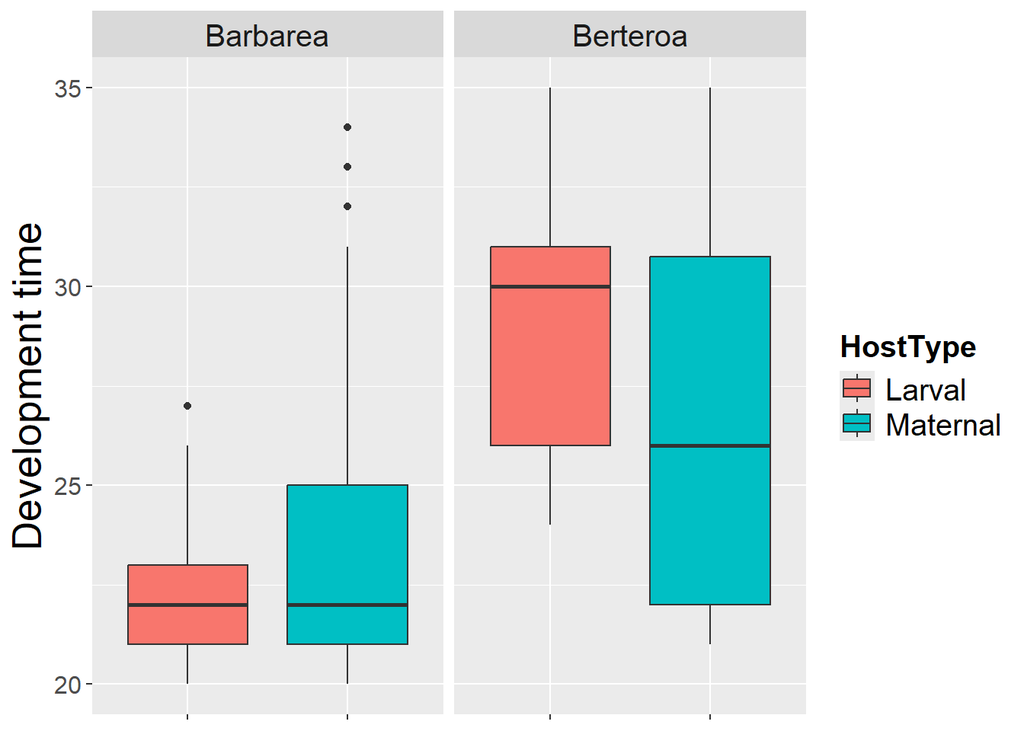

```r
ggplot(long_small_butterflies, aes(
  x = interaction(HostType, HostPlant),
  y = DevelopmentTime,
  fill = HostType)) +
  geom_boxplot() +
labs(y = "Development time", x = NULL) +
  scale_fill_discrete(labels=c('Larval', 'Maternal')) +
  facet_wrap(~ HostPlant, scales = "free_x", nrow = 1) +
  theme(axis.text.x = element_blank(),
        axis.text.y = element_text(size=12),
        axis.title.y = element_text(size=20),
        legend.text = element_text(size = 15),
        legend.title = element_text(face="bold",size=15),
        # Barbarea and Berteroa size
        strip.text = element_text(size = 15))
```